# Api di Diablo3

In questo tutorial vedremo come richiedere l'accesso alle api di diablo 3 e come utilizzarle per estrarre dati, per prima cosa bisogna andare sul sito https://develop.battle.net/ da cui potremo andare in 3 aree distinte, la pagina dove richiedere le api, la documentazione delle stesse e il forum della Blizzard dove poter fare domande e interagire con la comunity.

[figure not shown]

Per richiedere l'accesso alle api clicchiamo o su get started o su create client, in entrambi i casi ci verra chiesto di autenticarci con l'account blizzard o di crearne uno nuovo, inoltre se non fosse gia attiva ci viene richiesta di attivare l'autentificazione a due fattori. Dopo essersi autenticati ci si aprira questa pagina.

[figure not shown]

Cliccando su create client ci si aprira questa pagina.

[figure not shown]

Ci verranno chieste una serie di informazioni tra cui il nome della nostra applicazione e l'intento. Come redirect possiamo mettere "https://127.0.0.1" ovvero l'indirizzo locale che ci reinderizzera sulla nostra macchina e se non ne abbiamo uno possiamo spuntare la casella "i don not have a service URL for this client". Dopo aver cliccato save ci si aprirà questa pagina

[figure not shown]

Da qui possiamo prendere il client id e il client secret che come vedremo ci serviranno per autenticarci.

Ora che abbiamo le credenziali possiamo vedere quale è il link a cui fare le richieste, il link base é "https://%region.api.blizzard.com" dove al posto di %region va aggiunto eu per l'Europa, us per il Nord America, kr per la Corea e tw per Taiwan mentre per la Cina il link è "https://gateway.battlenet.com.cn/" inoltre ogni server ha una serie di lingue locali in cui può rispondere il server, la lista completa può0 essere trovata sulla pagina "https://develop.battle.net/documentation/guides/regionality-and-apis".

Ora andiamo sulla pagina "https://develop.battle.net/documentation", qui è possibile trovare tutta la documentazione sull'uso delle api, in particolare noi vedremo quelle di Diablo 3 ma l'uso per gli altri giochi è analogo.

[figure not shown]

Per ogni Gioco è possibile usare 2 tipi di api, i game data ovvero i dati del gioco come le informazioni sulle quest di world of warcraft o le informazioni su tutte le carte di Hearthstone, e i community data ovvero tutte le informazioni sui giocatori come i profili dei giocatori di starcraft e di diablo oppure gli inventari dei personaggi di diablo 3 e world of warcraft.

Noi in particolare useremo il secondo tipo ovvero le community data al fine di analizzare le abitudini dei giocatori. Nella pagina "https://develop.battle.net/documentation/diablo-3/community-apis" è possibile vedere tutte le possibili richieste da poter fare al server e testarle inserendo il client id e il client secret

[figure not shown]

Noi in particolare useremo il secondo tipo ovvero le community data al fine di analizzare le abitudini dei giocatori. Per esempio mettiamo di voler prendere le informazioni sull'account di un giocatore.

[figure not shown]

L'account del giocatore è identificato dal battletag ovvero un nome utente univoco fornito dalla blizzard per tutti i loro giochi (in questo caso per l'esempio ho usato il mio personale), il server risponderà a tutte le richieste con un json, in particolare il json di questa richiesta è il seguente:

.....

Questo è parte del json che contiene tutte le informazioni sul giocatore, in particolare contiene una lista che contiene tutti i personaggi creati dal giocatore e una serie di statistiche tra cui il tempo giocato con ogni classe e il numero di nemici elite uccisi etc... al fine di questo tutorial useremo solo la lista dei personaggi creati al fine di trovare quali sono gli item più giocati per ogni classe.

# Uso delle api in python

Abbiamo visto come testare le api dal sito stesso e come il sito ci risponde, ora l'obiettivo è automatizzare grazie a python questo processo e cercare di trovare qualche statistica rilevante tra i migliori giocatori d'Europa, per farlo per prima cosa dobbiamo avere un access token, in python grazie alla libreria request possiamo usare il seguente codice per ottenere il nostro token inserendo le credenziali del nostro client(N.B. il seguente codice non è presente in questo notebook come codice eseguibile perchè per via della limitazioni temporali delle richieste impiega circa 5 ore per essere eseguito).

```
import requests
import json
def create_access_token(client_id, client_secret, region = 'eu'):
    data = { 'grant_type': 'client_credentials' }
    response = requests.post('https://%s.battle.net/oauth/token' % region, data=data, auth=(client_id, client_secret))
    return response.json()

credenziali = create_access_token('il nostro client id', 'il nostro client secret'
```

Come risposta ci verrà dato il seguente json sotto forma di dizionario,

{'access_token': 'EUp89Q8N7HSSc1mT05TJRaNNke7y7yqDzK', 'token_type': 'bearer', 'expires_in': 86399, 'sub': '1dbd24e5fef24b989c5388f9d91acdea'}

L'access token è quello che dovremo inserire nell'url per autenticarci ad ogni richiesta e ottenere delle risposte dal server mentre il campo "expires_in" ci dice per quanto ancora sarà valido il token, secondo la documentazione fornita dalla blizzard un access token sarà valido per 24 ore dal momento dalla sua richiesta.

Ora che abbiamo il nostro access token facciamo una richiesta al server per ottenere la classifica dei 1000 giocatori con più achievement point in Europa di questa season.

```
classifica = requests.get('https://eu.api.blizzard.com/data/d3/season/24/leaderboard/achievement-points?locale=it_IT&access_token='+credenziali["access_token"])
classifica_json=classifica.json()


lista_nomi_utente=[]

for x in classifica_json["row"]:
    lista_nomi_utente.append(x["player"][0]["data"][0]["string"])
```

Analizziamo l'url a cui è stata fatta la richiesta "https://eu.api.blizzard.com", è l'indirizzo di base per il server Europeo di cui abbiamo gia parlato, "/data/d3/season/24/leaderboard/achievement-points" è la parte di indirizzo che identifica il dato che ci interessa, in questo caso il "season/24" identifica la season corrente, volendo è possibile richiedere lo stesso dato cambiando questo valore per ottenere le classifiche delle season passate. E' possibile anche cambiare "achievement-points" con il nome di un'altra classifica per ottenerne una diversa come ad esempio la classifica "rift-barbarian", essa identifica la classifica dei giocatori che hanno impiegato meno tempo per completare determinate missioni con la classe del barbaro. Infine la parte finale dell'url contiene due variabili ovvero il locale che come abbiamo detto è la lingua in cui vogliamo la risposta nel nostro caso l'Italiano e l'access token che abbiamo ottenuto precendetemente.

Alla fine del codice creiamo una lista composta dei nomi dei giocatori presenti nella lista.

Ora che abbiamo una lista dei migliori giocatori per ognuno di loro andiamo ad estrarre le informazioni sul suo profilo con il seguente codice python e creiamo un lista di json per contenere tutte le informazioni estratte.

```
account_information_json_list=[]
i=0

for x in lista_nomi_utente:

    while True:
        try:
            risposta = requests.get('https://eu.api.blizzard.com/d3/profile/'+x.replace("#",'%23')+'/?locale=it_IT&access_token='+credenziali["access_token"])
        except:
            continue
        break


    i=i+1
    print(str(i)+"  "+str(risposta))
    sleep(0.1)
    account_information_json_list.append(risposta.json())
```

Analizziamo l'url a cui facciamo la richiesta, come prima abbiamo il link base a cui concateniamo "d3/profile/'+x.replace("#",'%23')", dobbiamo sostituire il cancelletto perche non è un simbolo valido negli url, mentre come variabili come prima mettiamo la lingua in cui vogliamo la risposta e l'access token.

Inoltre inseriamo la richiesta dentro una while true perchè potrebbe capitare che il server ci metta troppo tempo a rispondere e la richiesta fallisca generando un erorre, inoltre inseriamo una sleep di 0.1 secondi per evitare di superare il limite di richiesta al secondo imposto dalla Blizzard.

Abbiamo dunque ottenuto una lista contenente tutte le informazioni di ogni account ma per i nostri scopi ci interessa avere solo avere le inforamazioni legate ai personaggi creati da ogni giocatore, quindi con il seguente codice inseriamo le informazioni che ci interessano in due struttera dati diverse, data sarà una lista di tuple dove ogni tupla conterrà il nome del giocatore e una lista degli id dei personaggi stagionali e di livello 70 che ha creato, invece dizionario conterrà le informazioni di ogni personaggio creato. Per ora prendiamo solo la classe ma dopo inseriremo anche le informazioni relative al suo inventario.

```
i=0

data=[]
dizionario={}

for y in account_information_json_list:
    try:
        y["battleTag"]
    except:
        print("nome sbagliato")
        continue

    i=i+1

    data.append((y["battleTag"],[]))

    for x in y["heroes"]:
        if(x["seasonal"]==True and x["level"]==70):
            data[len(data)-1][1].append(x["id"])
            dizionario[str(x["id"])]={"classe":x["class"]}
```

La try expcept è necessaria perchè anche se la richiesta nel precendente step è andata a buon fine può capitare che i nomi degli utenti nella classifica siano diversi rispetto al nome registrato sul server(il problema è legato alla possibilità di cambio di battle tag offerto dalla Blizzard che cambia il nome visualizzato nella classifica solo nella season successiva al cambio del battle tag) nel nostro caso solo 3 utenti non sono stati caricati correttamente.

Ora che abbiamo la lista con tutti i nomi e gli id dei personaggi completiamo il dizionario dei personaggi con gli inventari di tutti i personaggi.

Per ogni personaggio dovremo fare una richiesta al server, considerando che abbiamo circa 5000 personaggi il seguente codice sarà molto lento.

```
i=0

for x in data:
    i=i+1
    print(i)

    for y in x[1]:

        while True:
            try:
                risposta = requests.get('https://eu.api.blizzard.com/d3/profile/'+x[0].replace("#",'%23')+'/hero/'+str(y)+'/items/?locale=it_IT&access_token='+credenziali["access_token"])
            except:
                print("qui")
                continue
            break

        sleep(0.1)

        try:
            equip=risposta.json()
        except:
            for pezzo in pezzi_corpo:
                print("il pg non esiste")
                dizionario[str(y)][pezzo]={"nome":"no","id":"no"}
                dizionario[str(y)][pezzo]["set"]="NO"
            continue

        for pezzo in pezzi_corpo:
            try:
                dizionario[str(y)][pezzo]={"nome":equip[pezzo]["name"],"id":equip[pezzo]["id"]}
            except:
                dizionario[str(y)][pezzo]={"nome":"no","id":"no"}

            try:
                dizionario[str(y)][pezzo]["set"]=equip[pezzo]["set"]["slug"]
            except:
                dizionario[str(y)][pezzo]["set"]="NO"
```

Come prima avremo la richiesta in se dentro un while in modo che se la richiesta fallisce per un errore di connessione essa venga riprovata e una sleep per evitare di sforare il limite di richiesta all'ora.

Inoltre potrebbe capitare che per un qualche errore il contenuto del personaggio non venga caricato correttamente, questo viene gestito grazie a una try, inoltre se un personaggio non ha un oggetto nell'invetario questo non sarà presente nel json, questo provocherebbe un errore che farebbe fallire il programma di conseguenza anche questo viene gestito con una try e in caso di fallimento viene messo il seguente campo {"nome":"no","id":"no"}

Dopo aver eseguito i precedenti codici abbiamo genereto 2 strutture dati, per usare queste struttere usiamo la libreria pickle per salvarle in un file binario e tramite la stessa libreria ripristinarli in questo notebook.

```
file2=open("nomi utenti e eroi", "wb")
pickle.dump(data,file2)

file2.close()

file2=open("nomi utenti e eroi", "rb")
data2=pickle.load(file2)
file2.close()
```

# analisi dei dati

Per prima cosa ricarichiamo le strutture dati che abbiamo creato con il codice visto prima e creiamo due array che ci serviranno per scorrere il dizionario dei personaggi.

```python
import pickle
import json
import numpy as np
import matplotlib.pyplot as plt
from collections import Counter as counter
import operator

file2=open("dump item usati", "rb")
personaggi=pickle.load(file2)
file2.close()

file2=open("nomi utenti e eroi", "rb")
data=pickle.load(file2)
file2.close()

tipi_eroi=["monaco","monaca","cacciatore-di-demoni","cacciatrice-di-demoni","barbaro","barbara","crociato","crociata","mago","maga","sciamano","sciamana","negromante"]

slot_equipaggiamento=["head","neck","torso","shoulders","legs","waist","hands","bracers","feet","leftFinger","rightFinger","mainHand","offHand"]
```

Prima di procedere con l'analisi vera e propria filtriamo i dati, nel precedente codice abbiamo preso solo i personaggi stagionali a livello massimo e inoltre nel caso in cui i dati di un personaggio non siano stati caricati correttamente abbiamo inserito dei "no" come dati, per evitare di includere nelle statistiche dati di personaggi non rilevanti eliminiamo tutti i personaggi con meno di 7 item su 13.

```python
for x in data:
    for y in x[1]:
        i=0
        k=0
        while(k<7 and i<len(slot_equipaggiamento)):
            if(personaggi[str(y)][slot_equipaggiamento[i]]["id"]=="no"):
                k=k+1
            i=i+1

        if(k==7):
            del personaggi[str(y)]
            x[1].remove(y)
```

Per procedere con l'analisi considerando la natura del gioco é conveniente dividere i personaggi per classe.

Inseriamo i personaggi in un dizionario che ha come chiave il nome della classe e che contiene una lista dei personaggi di quella classe.

```python
count=0

eroi_per_tipo={}

for x in tipi_eroi:
    eroi_per_tipo[x]=[]

for x in data:

    for y in x[1]:
        (eroi_per_tipo[personaggi[str(y)]["classe"]]).append(y)
        count=count+1

print(count)
```

```
4596
```

```python
numero={}

for x in tipi_eroi:
    numero[x]=len(eroi_per_tipo[x])


group_data = list(numero.values())
group_names = list(numero.keys())
group_mean = np.mean(group_data)

%matplotlib inline

fig, ax = plt.subplots()
ax.barh(group_names, group_data)
ax.set( xlabel="N. eroi giocati", ylabel='Classi eroi',title=('classi giocate'))

print()
```

[figure not shown]

Ora invece vogliamo rappresentare il genere dei pg più giocati e vogliamo raggruppare i personaggi senza tener conto del genere.

```python
numeri_per_sesso={
    "maschi":0,
    "femmine":0
}
numeri_classi_no_sesso={}

i=0
while(i<len(tipi_eroi)-1):
    numeri_per_sesso["maschi"]=numeri_per_sesso["maschi"]+len(eroi_per_tipo[tipi_eroi[i]])
    numeri_per_sesso["femmine"]=numeri_per_sesso["femmine"]+len(eroi_per_tipo[tipi_eroi[i+1]])

    numeri_classi_no_sesso[tipi_eroi[i]]=len(eroi_per_tipo[tipi_eroi[i]])+len(eroi_per_tipo[tipi_eroi[i+1]])

    i=i+2

numeri_classi_no_sesso["negromante"]=len(eroi_per_tipo["negromante"])

group_data = list(numeri_per_sesso.values())
group_names = list(numeri_per_sesso.keys())
group_mean = np.mean(group_data)


fig, ax = plt.subplots(figsize=(12,4))
ax.barh(group_names, group_data)
ax.set( xlabel='N. pg ', ylabel='Gender',title=("stat gender"))

group_data = list(numeri_classi_no_sesso.values())
group_names = list(numeri_classi_no_sesso.keys())
group_mean = np.mean(group_data)


fig, ax = plt.subplots(figsize=(12,4))
ax.barh(group_names, group_data)
ax.set( xlabel='N. pg', ylabel='Classi eroi',title=("stat eroi giocati"))
print()
```

[figure not shown]

Ora analizziamo gli item più usati dai giocatori per ogni classe, e per prima cosa creiamo un dizionario apposito per contare gli item usati.

```python
dict_classe_item={}

for x in tipi_eroi:
    dict_classe_item[x]={}
    for y in slot_equipaggiamento:
        dict_classe_item[x][y]=[]

for x in data:

    for y in x[1]:

        for h in slot_equipaggiamento:
            #if(personaggi[str(y)][h]["id"]!="no"):
            dict_classe_item[personaggi[str(y)]["classe"]][h].append(personaggi[str(y)][h]["nome"])
```

Ora vogliamo creare dei grafici a barre per mostrare quali sono gli item più usati rispetto agli altri, per farlo per prima cosa creiamo il dizionario lista_stat_item_gender_less in cui raccogliamo per ogni classe (senza tenere conto del gender del pg) l'utilizzo di ogni singolo item. Il dizionario avrà come chiave la classe del pg e conterrà a sua volta un dizionario che avrà come chiave lo slot dell'equipaggiamento e conterrà un dizionario restituito dalla funzione counter contenuta nella libreria collection.

Questo dizionario avrà come chiave il nome dell'item e conterrà il numero di volte che si presenta nella lista.

```python
lista_stat_item_gender_less={}

i=0

while(i<len(tipi_eroi)-1):

    lista_stat_item_gender_less[tipi_eroi[i]]={}
    for y in slot_equipaggiamento:

        lista_stat_item_gender_less[tipi_eroi[i]][y]=counter(dict_classe_item[tipi_eroi[i]][y]+dict_classe_item[tipi_eroi[i+1]][y])
    i=i+2


lista_stat_item_gender_less[tipi_eroi[len(tipi_eroi)-1]]={}

for y in slot_equipaggiamento:
    lista_stat_item_gender_less[tipi_eroi[len(tipi_eroi)-1]][y]=counter(dict_classe_item[tipi_eroi[len(tipi_eroi)-1]][y])


#print(counter(dict_classe_item[x][y]).keys())
#print(counter(dict_classe_item["monaco"][slot_equipaggiamento[0]]).values())
```

```python
classe= 0

for y in slot_equipaggiamento:

    sortedDict = sorted(lista_stat_item_gender_less[tipi_eroi[classe]][y].items(), key=operator.itemgetter(1),reverse=True)

    group_data=[]
    group_names=[]

    if len(sortedDict)<10:
        dim=len(sortedDict)
    else:
        dim=int((len(sortedDict)/2))

    for x in sortedDict[:dim]:
        group_data.append(x[1])
        group_names.append(x[0])

    #roup_mean = np.mean(group_data)


    fig, ax = plt.subplots(figsize=(12,4))
    ax.barh(group_names, group_data)
    labels = ax.get_xticklabels()
    plt.setp(labels, rotation=45, horizontalalignment='right')
    ax.set( xlabel='numero di pg che lo usano', ylabel='Item',title=(tipi_eroi[classe]+"--"+y))
```

[figure not shown]

Ora facciamo lo stesso lavoro che abbiamo fatto, questa volta tenendo conto del genere dei pg per vedere se i grafici a barre sono simili. Per prima cosa creiamo una struttura dati apposita.

```python
lista_stat_item={}

for x in tipi_eroi:
    lista_stat_item[x]={}
    for y in slot_equipaggiamento:
        lista_stat_item[x][y]=counter(dict_classe_item[x][y])
```

E ora mostriamo i dati confrontando i dati dei pg maschili accanto a quelli femminili.

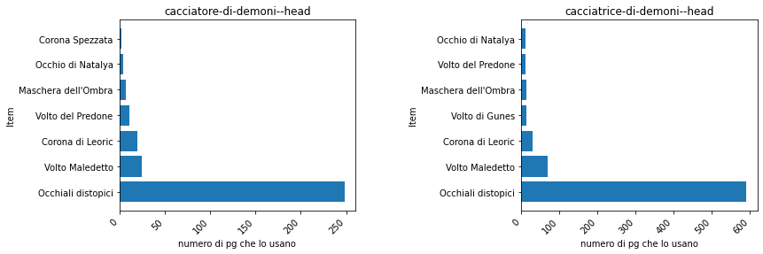

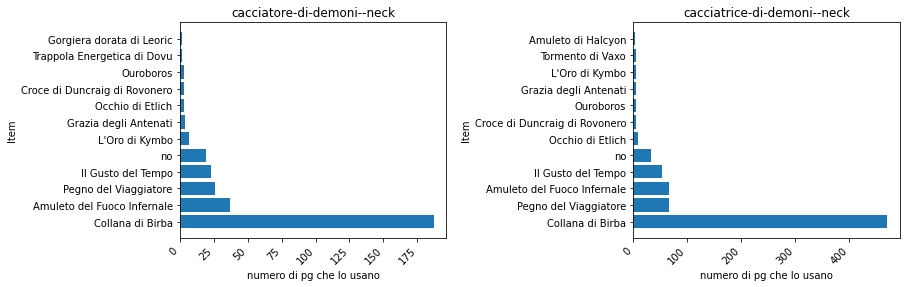

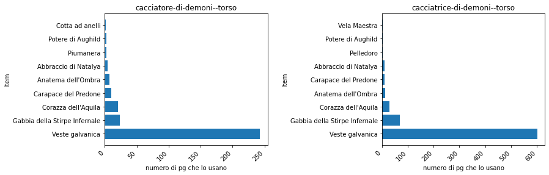

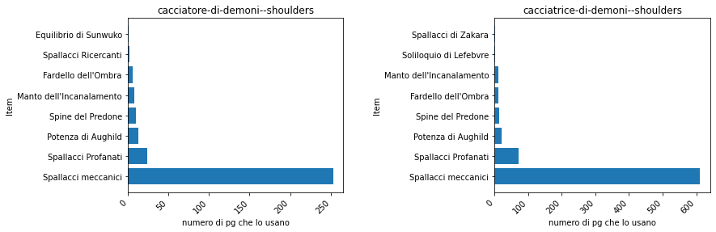

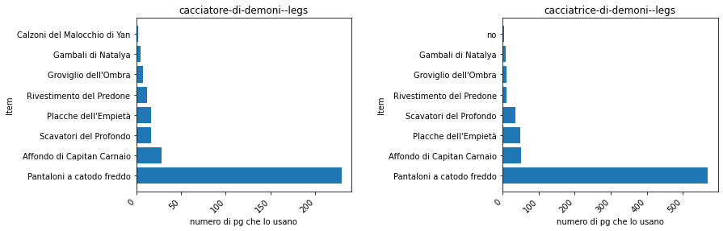

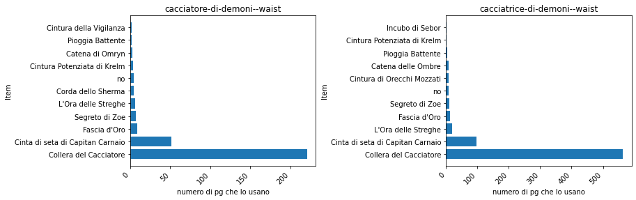

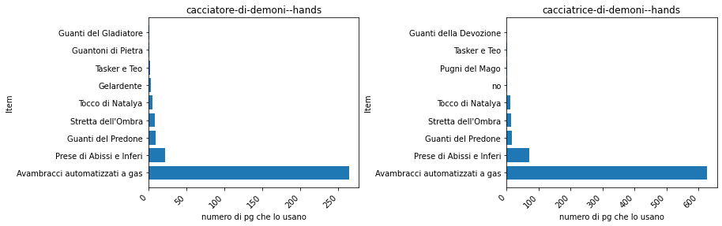

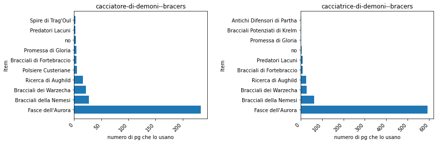

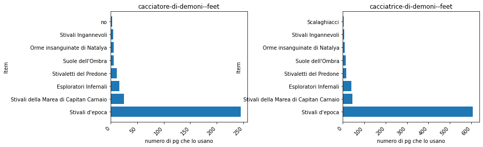

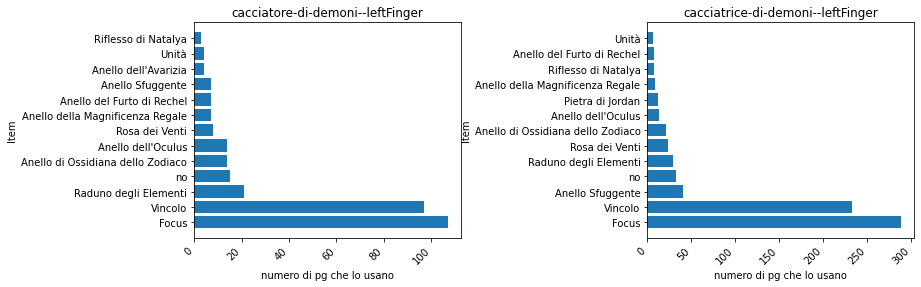

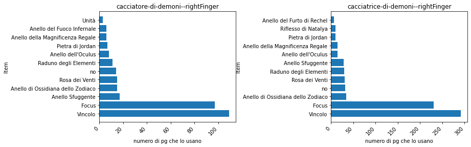

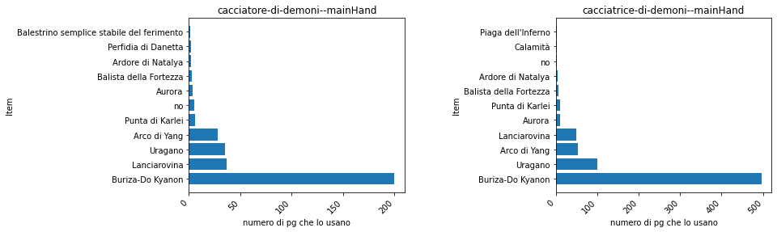

[1 more figures not shown]

```python
classe= 2

for y in slot_equipaggiamento:

    sortedDict = sorted(lista_stat_item[tipi_eroi[classe]][y].items(), key=operator.itemgetter(1),reverse=True)
    sortedDict1 = sorted(lista_stat_item[tipi_eroi[classe+1]][y].items(), key=operator.itemgetter(1),reverse=True)

    group_data=[]
    group_names=[]

    group_data1=[]
    group_names1=[]

    if int((len(sortedDict)/2))<5:
        dim=len(sortedDict)
    else:
        dim=int((len(sortedDict)/2))


    if int((len(sortedDict1)/2))<5:
        dim1=len(sortedDict1)
    else:
        dim1=int((len(sortedDict1)/2))

    if(dim1>dim):
        dim=dim1

    for x in sortedDict[:dim]:
        group_data.append(x[1])
        group_names.append(x[0])

    for x in sortedDict1[:dim]:
        group_data1.append(x[1])
        group_names1.append(x[0])


    fig, (ax,ax1) = plt.subplots(1,2,figsize=(10,5))
    fig.subplots_adjust(left=0, right=1,bottom=0,top=0.6,hspace=0.4, wspace=0.7)
    ax.barh(group_names, group_data)
    labels = ax.get_xticklabels()
    plt.setp(labels, rotation=45, horizontalalignment='right')
    ax.set( xlabel='numero di pg che lo usano', ylabel='Item',title=(tipi_eroi[classe]+"--"+y))


    ax1.barh(group_names1, group_data1)
    labels = ax1.get_xticklabels()
    plt.setp(labels, rotation=45, horizontalalignment='right')
    ax1.set( xlabel='numero di pg che lo usano', ylabel='Item',title=(tipi_eroi[classe+1]+"--"+y))
```

# Conclusioni

Le api di Blizzard sono abbastanza facili da usare e permettono l'accesso a una grande quantità di dati sugli utenti che potrebbero essere usati per diversi scopi, ad esempio allenare un'intelligenza artificiale per consigliare ai nuovi utenti quali item usare.